# Homework_10

Carlos Amissah

2024-04-10

###Q1. Using a for loop, write a function to calculate the number of zeroes in a numeric vector. Before entering the loop, set up a counter variable counter <- 0. Inside the loop, add 1 to counter each time you have a zero in the vector. Finally, use return(counter) for the output.

```r
z <- rbinom(n= 20,size=1, prob=0.5)# generates random numbers of zeroes and ones
count <- function(z_input) {
  counter <- 0
  for (i in 1:length(z_input)) {
    counter <- counter + as.numeric(z_input[i]==0)
  }
  return(counter)
}
count(z_input=z)
```

```
## [1] 9
```

###Q2. Use subsetting instead of a loop to rewrite the function as a single line of code.

```r
z <- rbinom(n= 10,size=1, prob=0.5)
counter <- sum(z==0)
print(counter)
```

```
## [1] 5
```

###Q3. Write a function that takes as input two integers representing the number of rows and columns in a matrix. The output is a matrix of these dimensions in which each element is the product of the row number x the column number.

```r
z <- function(row,col){
  ma <- matrix(nrow = row, ncol = col)
  for (i in 1:nrow(ma)){
    for(j in 1:ncol(ma)){
      ma[i,j] <- i * j
    }
  }
  return(ma)
}
z(row = 2, col=3)
```

```
##      [,1] [,2] [,3]
## [1,]    1    2    3
## [2,]    2    4    6
```

###Q4a. Simulate a dataset with 3 groups of data, each group drawn from a distribution with a different mean. The final data frame should have 1 column for group and 1 column for the response variable.

```r
nGroup <- c("Ball", "Bell","Bag")
nSize <- c(100,100,100) # number of observations in each group
nMean <- c(17,21,32) # mean of each group
nSD <- c(3.5,2.7,0.9)
Classroom <- c(rnorm(n=nSize[1],mean = nMean[1],sd=nSD[1]),
               rnorm(n=nSize[2],mean = nMean[2],sd=nSD[2]),
               rnorm(n=nSize[3],mean = nMean[3],sd=nSD[3]))
TGroup <- rep(nGroup,nSize)
data1 <- data.frame(Classroom, TGroup)
print(data1)
```

```
##     Classroom TGroup
## 1   13.451272   Ball
## 2   16.049447   Ball
## 3   15.722378   Ball
## 4   21.693668   Ball
## 5   13.301299   Ball
## 6   17.068600   Ball
## 7   17.353631   Ball
## 8   17.507124   Ball
## 9   12.449144   Ball
## 10  12.330904   Ball
## 11  13.442957   Ball
## 12  16.146378   Ball
## 13  11.667410   Ball
## 14  14.970404   Ball
```

[output cut: 286 more lines]

```r
 str(data1)
```

```
## 'data.frame':    300 obs. of  2 variables:
##  $ Classroom: num  13.5 16 15.7 21.7 13.3 ...
##  $ TGroup   : chr  "Ball" "Ball" "Ball" "Ball" ...
```

###4b. Write a custom function that 1) reshuffles the response variable, and 2) calculates the mean of each group in the reshuffled data. Store the means in a vector of length 3.

```r
head(data1)
```

```
##   Classroom TGroup
## 1  13.45127   Ball
## 2  16.04945   Ball
## 3  15.72238   Ball
## 4  21.69367   Ball
## 5  13.30130   Ball
## 6  17.06860   Ball
```

```r
myfun <- function(data1) {
data1$Classroom <- sample(data1$Classroom)
nMean <- tapply(data1$Classroom,data1$TGroup,mean)
return(nMean)
}
NewMeans<- myfun(data1)
print(NewMeans)
```

```
##      Bag     Ball     Bell
## 23.74412 22.20233 23.67030
```

###4c. Use a for loop to repeat the function in b 100 times. Store the results in a data frame that has 1 column indicating the replicate number and 1 column for each new group mean, for a total of 4 columns.

```r
Replicated <- data.frame(replicate = 1:100)
for (i in 1:100) {
  repeatNewMeans <- myfun(data1)
  Replicated[i, c("replicate", "BallMean", "BagMean", "BellMean")] <- c(i, repeatNewMeans)
}
print(head(Replicated))
```

```
##   replicate BallMean  BagMean BellMean
## 1         1 22.24029 23.34240 24.03406
## 2         2 22.71422 23.03219 23.87034
## 3         3 23.21706 22.64764 23.75206
## 4         4 22.71649 24.14568 22.75458
## 5         5 23.74829 23.36402 22.50444
## 6         6 23.57363 23.10158 22.94154
```

###4d. Use qplot() to create a histogram of the means for each reshuffled group. Or, if you want a challenge, use ggplot() to overlay all 3 histograms in the same figure. How do the distributions of reshuffled means compare to the original means?

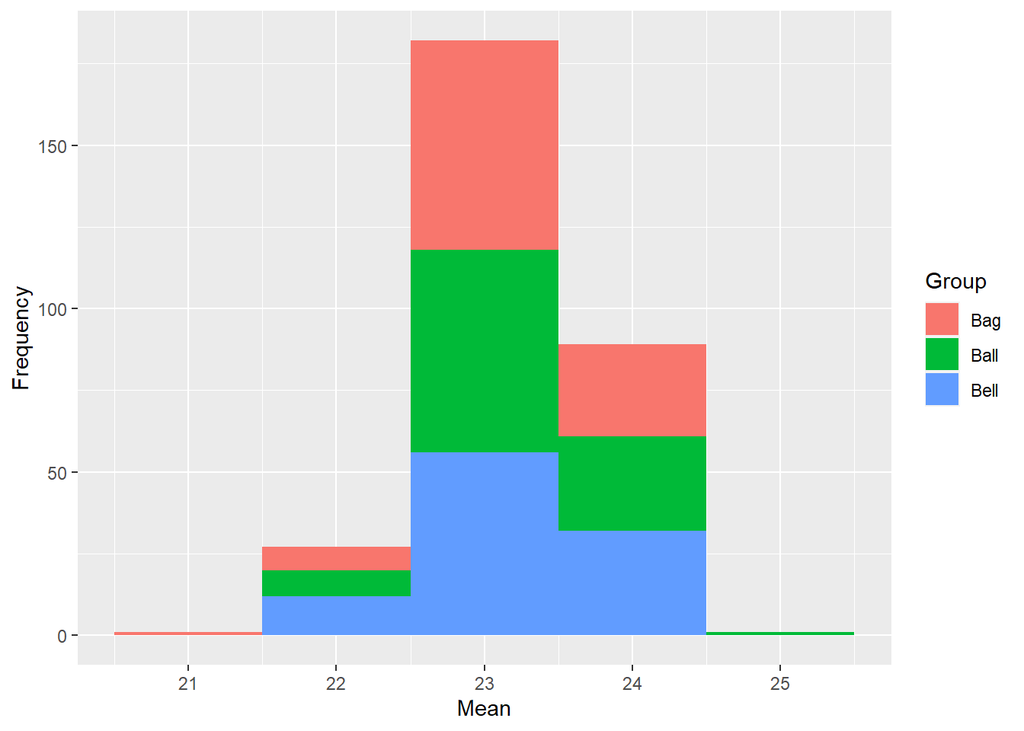

```r
library(ggplot2)
# Create a vector of means for each group
BallMeans <- Replicated$BallMean
BellMeans <- Replicated$BellMean
BagMeans <- Replicated$BagMean

# Combine means into a data frame
dataMeans <- data.frame(Group = rep(c("Ball", "Bell", "Bag"), each = 100),
                         Mean = c(BallMeans, BellMeans, BagMeans))

# Creating a histogram
qplot(data = dataMeans, x = Mean, fill = Group, geom = "histogram", binwidth = 1,
      xlab = "Mean", ylab = "Frequency")
```